# SSVEP reward - behavioral results

Ivan Grahek & Antonio Schettino

2019-07-03

## About the code

Experiment: FSAReward (Ivan Grahek*, Antonio Schettino*, Gilles Pourtois, Ernst Koster, & Søren Andersen) (*: co-first authors) Code written by: Ivan Grahek & Antonio Schettino (2016-2018) Description: Code for the analysis of behavioral data for Experiment 1 of the SSVEP - reward project.

### Accuracy data

```r
# Clear environemnt and import data------------------------------------------------------------------------------------------------------------------------------------------------------------------------------------------------------

# clear the environment
rm(list=ls())
# clear the console
cat("\014")
```

```r
#load packages and install them if they're not installed
if (!require("pacman")) install.packages("pacman")
pacman::p_load(plyr,Rmisc,yarrr,BayesFactor,reshape2,brms, broom, tidyverse, brmstools, BEST, knitr, here,psych)
# set seed
set.seed(42)
# set directory
setwd(here())
# import data
data.raw = read.csv(file = here("data","Data_behavior_exp1_48pps.csv"),header=TRUE,na.strings="NaN")

# Prepare the dataset------------------------------------------------------------------------------------------------------------------------------------------------------------------------------------------------------

### Adding and renaming variables
# rename EventType variable
names(data.raw)[names(data.raw) == "EventType"] = "MovedDots"
# add a variable with the name of the attended color instead of a numbers
data.raw$AttendedColor = ifelse(data.raw$AttendedColor==1,"red","blue")
# add a variable saying which color was linked with High_Rew (even numbers - blue was High_Rew)
data.raw$RewardedColor = ifelse(data.raw$ParticipantNo%%2==0,"blue","red")
# add a variable with the name of the moved color instead of a numbers
data.raw$MovedDots = ifelse(data.raw$MovedDots==1,"red","blue")
# split experimental phases into 6 isntead of 3 phases (trial 0-200: Bsln; trial 201-400: Acq; trial 401-600: Ext)
#data.raw$ExpPhase = cut(data.raw$Trial,breaks=c(0,100,200,300,400,500,600),labels=c("Bsln1","Bsln2","Acq1","Acq2","Ext1","Ext2"))
# split experimental phases into 3 phases (trial 0-200: Bsln; trial 201-400: Acq; trial 401-600: Ext)
data.raw$ExpPhase = cut(data.raw$Trial,breaks=c(0,200,400,600),labels=c("Bsln","Acq","Ext")) # trial 0-200: Bsln; trial 201-400: Acq; trial 401-600: Ext

### Convert variables to be used in analyses into factors
data.raw[c("ParticipantNo", "AttendedColor","RewardedColor", "MovedDots", "ExpPhase" )] =
  lapply(data.raw[c("ParticipantNo", "AttendedColor","RewardedColor", "MovedDots", "ExpPhase" )], factor)

### Create variables needed for the accuracy analyses
# count hits, false alarms, misses, correct rejections, and RT separately for each participant (their calculation is done in Matlab: see DataProcessing.m)
data.final = ddply(data.raw,.(ParticipantNo,ExpPhase,AttendedColor,RewardedColor,MovedDots),summarize,
                  numtrials=length(which(Response!=99)), # number of trials per condition (anything that is not 99 or any other number that we're not using)
                  Hits=length(which(Response==1)), # hits: attended color moved, correct response
                  FAs=length(which(Response==2)), # false alarms: attended color did not move, (wrong) response
                  Misses=length(which(Response==0)), # misses: attended color moved, no response
                  CRs=length(which(Response==3)), # correct rejections: attended color did not move, no response
                  mean.RT=mean(RT,na.rm=TRUE)) # mean RT per condition


################################################################## Calculate accuracy and RTs per condition ###############################################################################################################################################################################################################

# Prepare the data------------------------------------------------------------------------------------------------------------------------------------------------------------------------------------------------------

### Calculate Hits and False alarms
# Hits are calculated for each participant in each condition on trials when they are attending the color that moved.
# False alarms are  calculated for each participant in each condition on trials when they are attending the color that didn't move (the unattended color moved, but they responded)
# Here we create the same number of hits & fas for each of the two conditions (moved attended or not)
data.final = ddply(data.final, .(ParticipantNo,ExpPhase,AttendedColor), transform,
                 Hits = Hits[MovedDots==AttendedColor],
                 FAs = FAs[MovedDots!=AttendedColor])

# Keep only trials on which the attended color moved (we can do behavioral analysis only on those)
data.final = subset(data.final,MovedDots==AttendedColor)

### Calculate d'
# use loglinear transformation: add 0.5 to Hits, FAs, Misses, and CRs (Hautus, 1995, Behavior Research Methods, Instruments, & Computers),
# which is preferred over the 1/2N rule (Macmillan & Kaplan, 1985, Psychological Bulletin) because it results in less biased estimates of d'.
data.final =  ddply(data.final,.(ParticipantNo,ExpPhase,RewardedColor,AttendedColor,numtrials),summarise,
                    tot.Hits=Hits+.5, # hits
                    tot.FAs=FAs+.5, # false alarms
                    tot.Misses=(numtrials-Hits)+.5, # misses
                    tot.CRs=(numtrials-FAs)+.5, # correct rejections
                    Hit.Rate=tot.Hits/(tot.Hits+tot.Misses), # hit rate
                    FA.Rate=tot.FAs/(tot.FAs+tot.CRs), # false alarm rate
                    #dprime=qnorm(Hit.Rate)-qnorm(FA.Rate),
                    Hits.RTs=mean(mean.RT,na.rm=TRUE)) # mean RTs

# Calculate SDT indices with psycho
indices = psycho::dprime(data.final$tot.Hits, data.final$tot.FAs, data.final$tot.Misses, data.final$tot.CRs)

data.final = cbind(data.final, indices)


### Create a final dataframe for accuracy and RTs analyses
# add a new variable specifying whether the participant is attending the high or Low_Rewed color
data.final$Condition = ifelse(data.final$RewardedColor==data.final$AttendedColor,"High_Rew","Low_Rew")
# make this variable a factor for further analyses
data.final$Condition = factor(data.final$Condition)

# Exclude subjects with poor behavior
poor_behavior = c(15,17,31,34)
data.final = data.final[!data.final$ParticipantNo %in% poor_behavior,]
```

## D prime

### Means - D prime - raw data

```r
summary = ddply(data.final,.(ExpPhase,Condition),plyr::summarize,Mean=c(paste(round(mean(dprime, na.rm = TRUE), digits = 2), " [", round(hdi(dprime)[[1]], digits = 2), " ", round(hdi(dprime)[[2]], digits = 2), "]")))

names(summary) = c("Reward phase", "Reward probability", "Dprime")

summary$`Reward phase` = recode(summary$`Reward phase`,
                           "Acq" = "Acquisition",
                           "Bsln" = "Baseline",
                           "Ext" = "Extinction")

summary$`Reward probability` = recode(summary$`Reward probability`,
                           "High_Rew" = "High",
                           "Low_Rew" = "Low")

summary = as.data.frame(summary)

kable(summary, caption = "Dprime per condition")
```

Dprime per condition

| Reward phase | Reward probability | Dprime |
| --- | --- | --- |
| Baseline | High | 1.74 [ 0.37 2.68 ] |
| Baseline | Low | 1.49 [ 0.13 2.3 ] |
| Acquisition | High | 1.78 [ 0.68 2.73 ] |
| Acquisition | Low | 1.68 [ 0.46 2.55 ] |
| Extinction | High | 1.75 [ 0.69 2.73 ] |
| Extinction | Low | 1.68 [ 0.74 2.59 ] |

### Plot

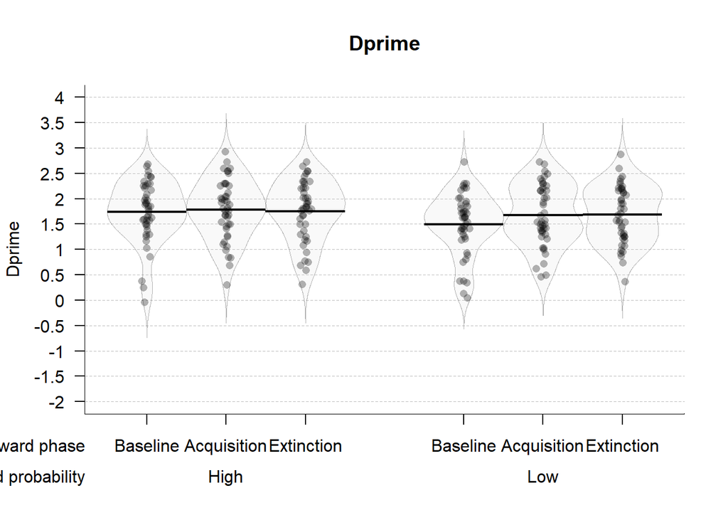

```r
# # Plot FA rates------------------------------------------------------------------------------------------------------------------------------------------------------------------------------------------------------
# Prepare the dataset
data.plot = data.final

# rename variables
colnames(data.plot)[colnames(data.plot)=="ExpPhase"] <- "Reward phase"
colnames(data.plot)[colnames(data.plot)=="Condition"] <- "Reward probability"

# rename conditions
data.plot$`Reward phase` = recode(data.plot$`Reward phase`,
                                "Acq" = "Acquisition",
                                "Bsln" = "Baseline",
                                "Ext" = "Extinction")

data.plot$`Reward probability` = recode(data.plot$`Reward probability`,
                                      "High_Rew" = "High",
                                      "Low_Rew" = "Low")
  # Pirate plot
  pirateplot(formula=dprime ~ `Reward phase` + `Reward probability`, # dependent~independent variables
             data=data.plot, # data frame
             main="Dprime", # main title
             ylim=c(-2,4), # y-axis: limits
             ylab="Dprime", # y-axis: label
             theme=0, # preset theme (0: use your own)
             point.col="black", # points: color
             point.o=.3, # points: opacity (0-1)
             avg.line.col="black", # average line: color
             avg.line.lwd=2, # average line: line width
             avg.line.o=1, # average line: opacity (0-1)
             bean.b.col="black", # bean border, color
             bean.lwd=0.6, # bean border, line width
             bean.lty=1, # bean border, line type (1: solid; 2:dashed; 3: dotted; ...)
             bean.b.o=0.3, # bean border, opacity (0-1)
             bean.f.col="gray", # bean filling, color
             bean.f.o=.1, # bean filling, opacity (0-1)
             cap.beans=FALSE, # max and min values of bean densities are capped at the limits found in the data
             gl.col="gray", # gridlines: color
             gl.lty=2, # gridlines: line type (1: solid; 2:dashed; 3: dotted; ...)
             cex.lab=1, # axis labels: size
             cex.axis=1, # axis numbers: size
             cex.names = 1,
             bty="l", # plot box type
             back.col="white") # background, color
```

### Statistics

```r
# Set the working directory in order to load the models
# Set working directory
setwd(here("brms_models"))
#
# # Null model
# model.null.Acc.dprime = brm(dprime ~ 1 + (1|ParticipantNo),
#                         data=data.final,
#                         family=gaussian(),
#                         warmup = 2000,
#                         iter = 10000,
#                         save_all_pars = TRUE,
#                         control = list(adapt_delta = 0.99),
#                         cores = 4,
#                         sample_prior = TRUE)
# saveRDS(model.null.Acc.dprime,file="nullmodel.Acc.dprime.rds")
#
# # ExpPhase model
# model.expphase.Acc.dprime = brm(dprime ~ ExpPhase + (ExpPhase|ParticipantNo),
#                             data=data.final,
#                             family=gaussian(),
#                             warmup = 2000,
#                             iter = 10000,
#                             save_all_pars = TRUE,
#                             control = list(adapt_delta = 0.99),
#                             cores = 4,
#                             sample_prior = TRUE)
# saveRDS(model.expphase.Acc.dprime,file="expphasemodel.Acc.dprime.rds")
#
# #Interaction model
# model.full.Acc.dprime = brm(dprime ~ ExpPhase * Condition + (ExpPhase * Condition|ParticipantNo),
#                         data=data.final,
#                         family=gaussian(),
#                         warmup = 2000,
#                         iter = 10000,
#                         save_all_pars = TRUE,
#                         control = list(adapt_delta = 0.99),
#                         cores = 4,
#                         sample_prior = TRUE)
# saveRDS(model.full.Acc.dprime,file="model.full.Acc.dprime.rds")
#
# #read in the models and comparisons
# # model.null.Acc.FA = readRDS("nullmodel.Acc.FA.rds")
# # model.expphase.Acc.FA = readRDS("expphasemodel.Acc.FA.rds")
# # model.full.Acc.FA = readRDS("model.full.Acc.FA.rds")
# # compare.waic.Acc = readRDS("compare.Acc.waic")
#
# #WAIC
# compare.Acc.dprime.waic = WAIC(model.null.Acc.dprime,model.expphase.Acc.dprime,model.full.Acc.dprime, compare = TRUE)
# saveRDS(compare.Acc.dprime.waic,file="compare.Acc.dprime.waic")
#
# # Weighted waic
# compare.Acc.dprime.waic.weights = model_weights(model.null.Acc.dprime,model.expphase.Acc.dprime,model.full.Acc.dprime, weights = "waic")
# saveRDS(compare.Acc.dprime.waic.weights,file="compare.Acc.dprime.waic.weights")
#
# # Bayesian R2
# #Null
# bR2.null.Acc.dprime = bayes_R2(model.null.Acc.dprime)
# saveRDS(bR2.null.Acc.dprime,file="bR2.null.Acc.dprime")
# #ExpPhase
# bR2.expphase.Acc.dprime = bayes_R2(model.expphase.Acc.dprime)
# saveRDS(bR2.expphase.Acc.dprime,file="bR2.expphase.Acc.dprime")
# #Full
# bR2.full.Acc.dprime = bayes_R2(model.full.Acc.dprime)
# saveRDS(bR2.full.Acc.dprime,file="bR2.full.Acc.dprime")

model.full.Acc.dprime = readRDS("model.full.Acc.dprime.rds")
compare.waic.Acc.dprime = readRDS("compare.Acc.dprime.waic")
compare.Acc.dprime.waic.weights = readRDS("compare.Acc.dprime.waic.weights")
bR2.null.Acc.dprime = readRDS("bR2.null.Acc.dprime")
bR2.expphase.Acc.dprime = readRDS("bR2.expphase.Acc.dprime")
bR2.full.Acc.dprime = readRDS("bR2.full.Acc.dprime")
```

### Model comparison with WAIC

```r
print(compare.waic.Acc.dprime)
```

```
##                                                     WAIC    SE
## model.null.Acc.dprime                             446.33 23.43
## model.expphase.Acc.dprime                         451.47 22.74
## model.full.Acc.dprime                             200.57 21.27
## model.null.Acc.dprime - model.expphase.Acc.dprime  -5.14  3.35
## model.null.Acc.dprime - model.full.Acc.dprime     245.77 23.82
## model.expphase.Acc.dprime - model.full.Acc.dprime 250.91 23.53
```

### Model comparison with WAIC weights

```r
print(compare.Acc.dprime.waic.weights)
```

```
##     model.null.Acc.dprime model.expphase.Acc.dprime
##              4.284133e-54              3.283575e-55
##     model.full.Acc.dprime
##              1.000000e+00
```

### Bayesian R squared

Null model

```r
print(bR2.null.Acc.dprime)
```

```
##     Estimate  Est.Error     Q2.5     Q97.5
## R2 0.2229344 0.04885937 0.125037 0.3154086
```

Experiment phase model

```r
print(bR2.expphase.Acc.dprime)
```

```
##     Estimate  Est.Error      Q2.5     Q97.5
## R2 0.2396632 0.04856887 0.1427286 0.3314708
```

Full model

```r
print(bR2.full.Acc.dprime)
```

```
##     Estimate  Est.Error     Q2.5     Q97.5
## R2 0.7620456 0.02220512 0.714308 0.8017077
```

### Checking the best model

Plotting the chains

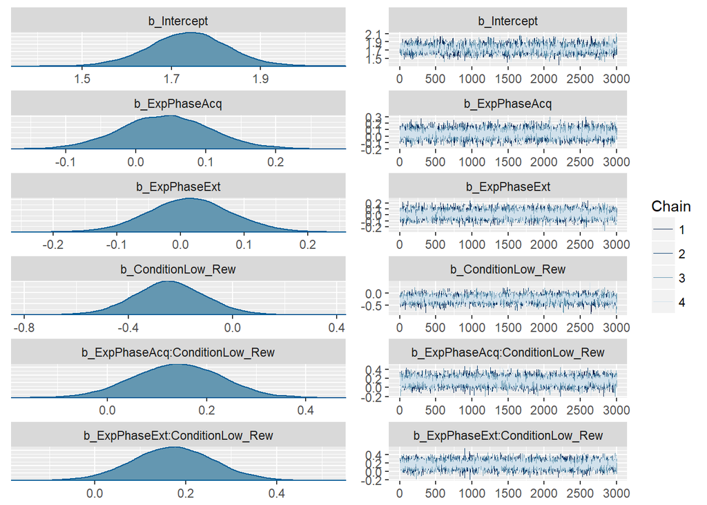

```r
# Plot chains
plot(model.full.Acc.dprime, pars = "^b_", ask = FALSE, N=6)
```

Summary of the best model

```r
# Summary of the best model
print(tidy(model.full.Acc.dprime, par_type = "non-varying"), digits = 1)
```

```
##                           term estimate std.error  lower upper
## 1                    Intercept     1.74      0.09  1.592  1.88
## 2                  ExpPhaseAcq     0.04      0.06 -0.063  0.15
## 3                  ExpPhaseExt     0.01      0.06 -0.091  0.12
## 4             ConditionLow_Rew    -0.24      0.14 -0.464 -0.02
## 5 ExpPhaseAcq:ConditionLow_Rew     0.14      0.09 -0.004  0.28
## 6 ExpPhaseExt:ConditionLow_Rew     0.17      0.09  0.024  0.32
```

### Plotting the best model

#### Sample from the posterior

```r
# Analyzing the posterior and differences between conditions

post = posterior_samples(model.full.Acc.dprime, "^b")


################################################ Baseline ####

######### High reward
Baseline_High = post[["b_Intercept"]]
######### Low reward
Baseline_Low = post[["b_Intercept"]] +
  post[["b_ConditionLow_Rew"]]

################################################ Acquistion

######### High reward
Acquisition_High = post[["b_Intercept"]] +
  post[["b_ExpPhaseAcq"]]
######### Low reward
Acquisition_Low = post[["b_Intercept"]] +
  post[["b_ExpPhaseAcq"]] +
  post[["b_ConditionLow_Rew"]] +
  post[["b_ExpPhaseAcq:ConditionLow_Rew"]]

################################################ Extinction

######### High reward
Extinction_High = post[["b_Intercept"]] +
  post[["b_ExpPhaseExt"]]
######### Low reward
Extinction_Low = post[["b_Intercept"]] +
  post[["b_ExpPhaseExt"]] +
  post[["b_ConditionLow_Rew"]] +
  post[["b_ExpPhaseExt:ConditionLow_Rew"]]
```

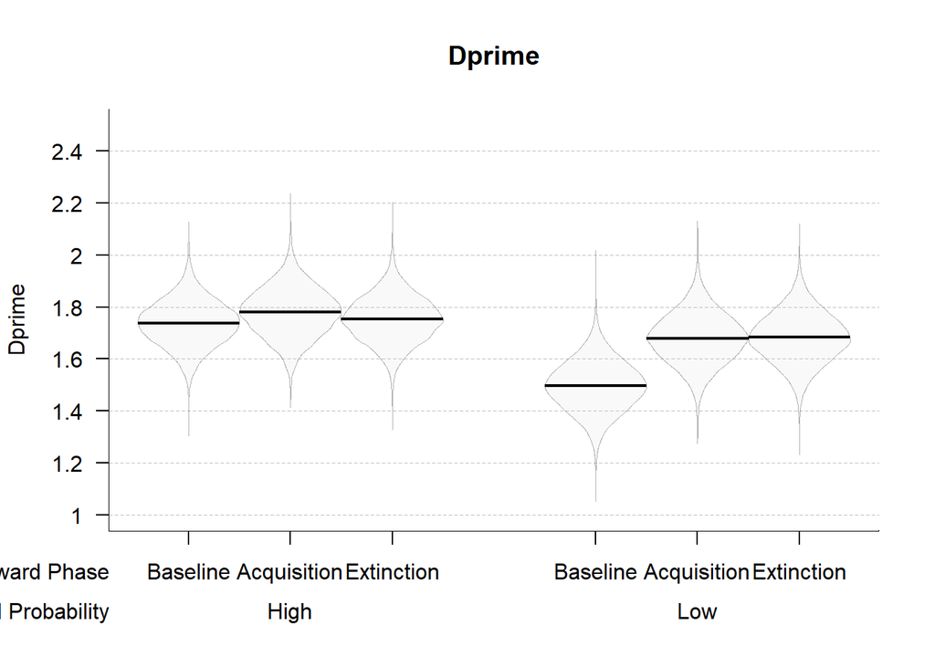

```r
# make a data frame
posterior_conditions = melt(data.frame(Baseline_High, Baseline_Low, Acquisition_High, Acquisition_Low, Extinction_High, Extinction_Low))

posterior_conditions =  posterior_conditions %>% separate(variable, c("Reward Phase", "Reward Probability"), "_", extra = "merge")

names(posterior_conditions)[3] = "Dprime"





# Pirate plot
pirateplot(formula = `Dprime` ~ `Reward Phase` + `Reward Probability`, # dependent~independent variables
             data=posterior_conditions, # data frame
             main="Dprime", # main title
             ylim=c(1, 2.5), # y-axis: limits
             ylab="Dprime", # y-axis: label
             theme=0, # preset theme (0: use your own)
             avg.line.col="black", # average line: color
             avg.line.lwd=2, # average line: line width
             avg.line.o=1, # average line: opacity (0-1)
             bean.b.col="black", # bean border, color
             bean.lwd=0.6, # bean border, line width
             bean.lty=1, # bean border, line type (1: solid; 2:dashed; 3: dotted; ...)
             bean.b.o=0.3, # bean border, opacity (0-1)
             bean.f.col="gray", # bean filling, color
             bean.f.o=.1, # bean filling, opacity (0-1)
             cap.beans=FALSE, # max and min values of bean densities are capped at the limits found in the data
             gl.col="gray", # gridlines: color
             gl.lty=2, # gridlines: line type (1: solid; 2:dashed; 3: dotted; ...)
             cex.lab=1, # axis labels: size
             cex.axis=1, # axis numbers: size
             cex.names = 1,
             sortx = "sequential",
             bty="l", # plot box type
             back.col="white") # background, color
```

Table of means across conditions

```r
library(HDInterval)

# Make a table with conditions
posterior_means = as.data.frame(c("Baseline High Reward",
                                  "Baseline Low Reward",
                                  "Acquisition High Reward",
                                  "Acquisition Low Reward",
                                  "Extinction High Reward",
                                  "Extinction Low Reward"))
names(posterior_means)[1] = "Condition"

posterior_means$Mean = c(paste(round(mean(Baseline_High), digits = 2), " [", round(hdi(Baseline_High)[[1]], digits = 2), " ", round(hdi(Baseline_High)[[2]], digits = 2), "]"),
                        paste(round(mean(Baseline_Low), digits = 2), " [", round(hdi(Baseline_Low)[[1]], digits = 2), " ", round(hdi(Baseline_Low)[[2]], digits = 2), "]"),
                        paste(round(mean(Acquisition_High), digits = 2), " [", round(hdi(Acquisition_High)[[1]], digits = 2), " ", round(hdi(Acquisition_High)[[2]], digits = 2), "]"),
                        paste(round(mean(Acquisition_Low), digits = 2), " [", round(hdi(Acquisition_Low)[[1]], digits = 2), " ", round(hdi(Acquisition_Low)[[2]], digits = 2), "]"),
                        paste(round(mean(Extinction_High), digits = 2), " [", round(hdi(Extinction_High)[[1]], digits = 2), " ", round(hdi(Extinction_High)[[2]], digits = 2), "]"),
                        paste(round(mean(Extinction_Low), digits = 2), " [", round(hdi(Extinction_Low)[[1]], digits = 2), " ", round(hdi(Extinction_Low)[[2]], digits = 2), "]"))

names(posterior_means)[2] = "Mean [HDI]"

posterior_means =  posterior_means %>% separate(Condition, c("Reward Phase", "Reward Probability"), " ", extra = "merge")

kable(posterior_means, caption = "Means per condition")
```

Means per condition

| Reward Phase | Reward Probability | Mean [HDI] |
| --- | --- | --- |
| Baseline | High Reward | 1.74 [ 1.55 1.9 ] |
| Baseline | Low Reward | 1.5 [ 1.31 1.69 ] |
| Acquisition | High Reward | 1.78 [ 1.59 1.96 ] |
| Acquisition | Low Reward | 1.68 [ 1.49 1.87 ] |
| Extinction | High Reward | 1.75 [ 1.58 1.93 ] |
| Extinction | Low Reward | 1.68 [ 1.49 1.87 ] |

### Inference about the best model

Check the difference between high reward in baseline vs. acquisition

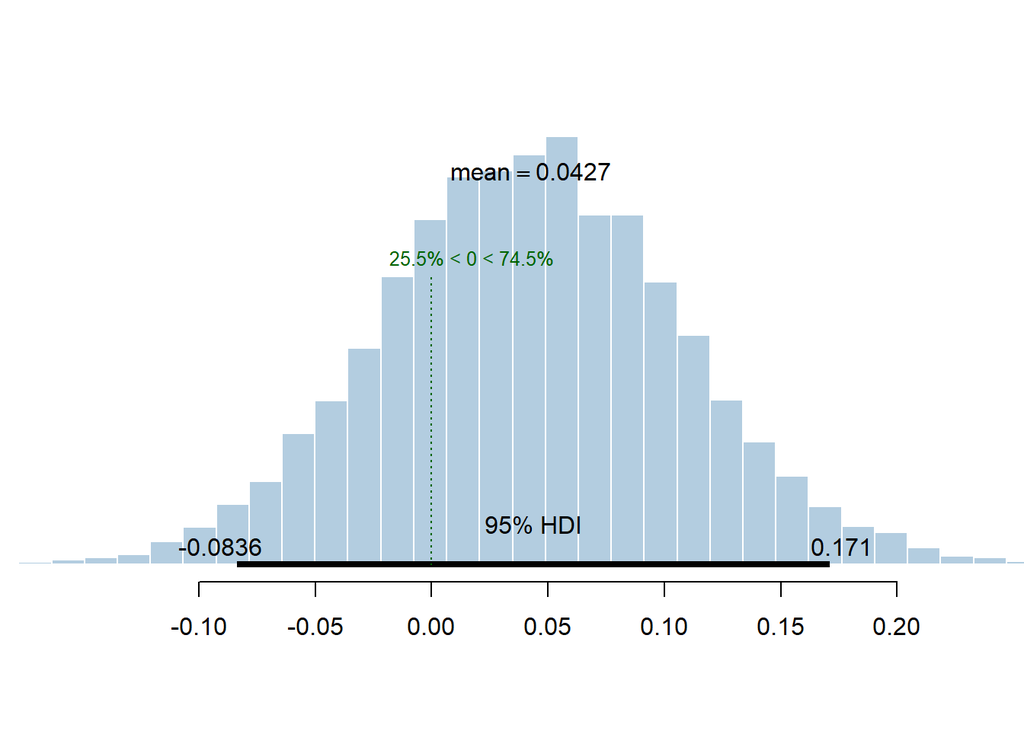

```r
Diff_Bsln_Acq_High = Acquisition_High - Baseline_High
plotPost(Diff_Bsln_Acq_High, xlab = "", col = "#b3cde0", showCurve = FALSE, cex = 1, compVal = 0)
```

Check the difference between low reward in baseline vs. acquisition

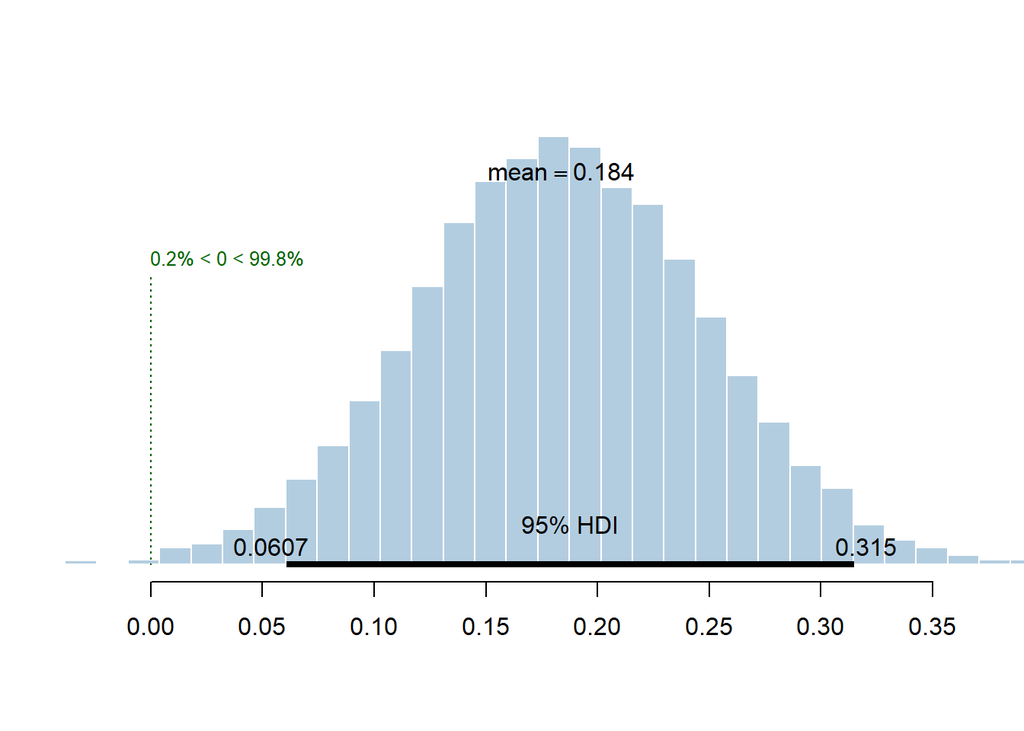

```r
Diff_Bsln_Acq_Low = Acquisition_Low - Baseline_Low
plotPost(Diff_Bsln_Acq_Low, xlab = "", col = "#b3cde0", showCurve = FALSE, cex = 1, compVal = 0)
```

Check the difference between high and low reward in baseline vs. acquisition

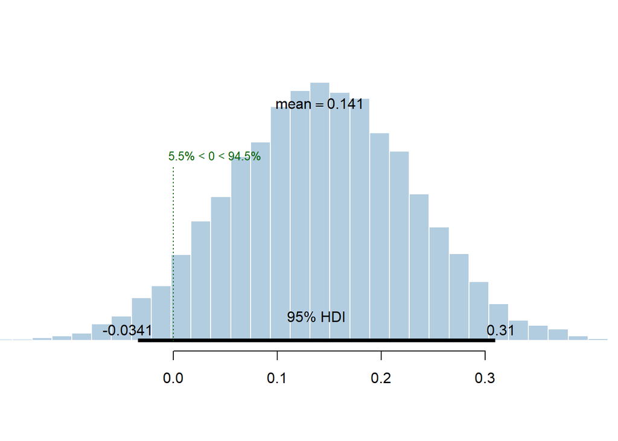

```r
Diff_Bsln_Acq_High_vs_Low = Diff_Bsln_Acq_Low - Diff_Bsln_Acq_High
plotPost(Diff_Bsln_Acq_High_vs_Low, xlab = "", col = "#b3cde0", showCurve = FALSE, cex = 1, compVal = 0)
```

```r
paste("Mean = ",round(mean(Diff_Bsln_Acq_High_vs_Low), digits = 2), " [", round(hdi(Diff_Bsln_Acq_High_vs_Low)[[1]], digits = 2), " ", round(hdi(Diff_Bsln_Acq_High_vs_Low)[[2]], digits = 2), "]")
```

```
## [1] "Mean =  0.14  [ -0.03   0.31 ]"
```

Check the difference between high reward in acquisition vs. extinction

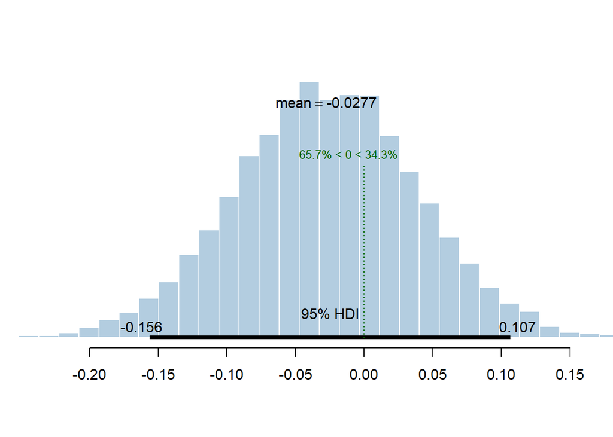

```r
Diff_Acq_Ext_High = Extinction_High - Acquisition_High
plotPost(Diff_Acq_Ext_High, xlab = "", col = "#b3cde0", showCurve = FALSE, cex = 1, compVal = 0)
```

Check the difference between low reward in acquisition vs. extinction

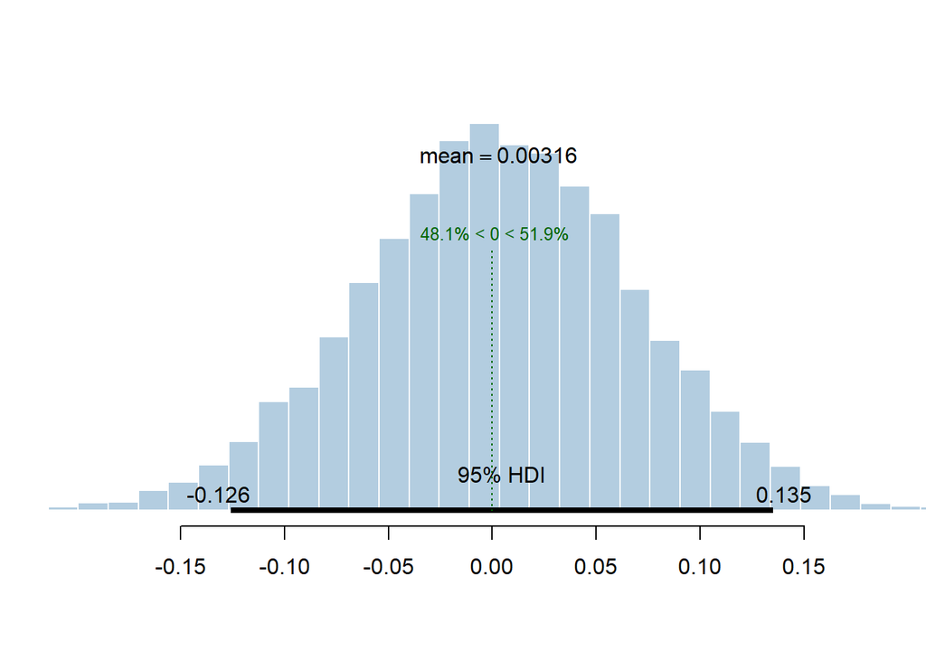

```r
Diff_Acq_Ext_Low = Extinction_Low - Acquisition_Low
plotPost(Diff_Acq_Ext_Low, xlab = "", col = "#b3cde0", showCurve = FALSE, cex = 1, compVal = 0)
```

## Reaction times

### Means - raw data

```r
summary = ddply(data.final,.(ExpPhase,Condition),plyr::summarize,Mean=c(paste(round(mean(Hits.RTs, na.rm = TRUE), digits = 2), " [", round(hdi(Hits.RTs)[[1]], digits = 2), " ", round(hdi(Hits.RTs)[[2]], digits = 2), "]")))

names(summary) = c("Reward phase", "Reward probability", "Reaction times")

summary$`Reward phase` = recode(summary$`Reward phase`,
                           "Acq" = "Acquisition",
                           "Bsln" = "Baseline",
                           "Ext" = "Extinction")

summary$`Reward probability` = recode(summary$`Reward probability`,
                           "High_Rew" = "High",
                           "Low_Rew" = "Low")

summary = as.data.frame(summary)

kable(summary, caption = "Reaction times per condition")
```

Reaction times per condition

| Reward phase | Reward probability | Reaction times |
| --- | --- | --- |
| Baseline | High | 551.21 [ 485.64 619.34 ] |
| Baseline | Low | 556.87 [ 470.68 630.88 ] |
| Acquisition | High | 528.86 [ 457.23 599.49 ] |
| Acquisition | Low | 542 [ 465.32 605.14 ] |
| Extinction | High | 533.01 [ 448.5 599.83 ] |
| Extinction | Low | 540.85 [ 455.8 623.21 ] |

### Plot

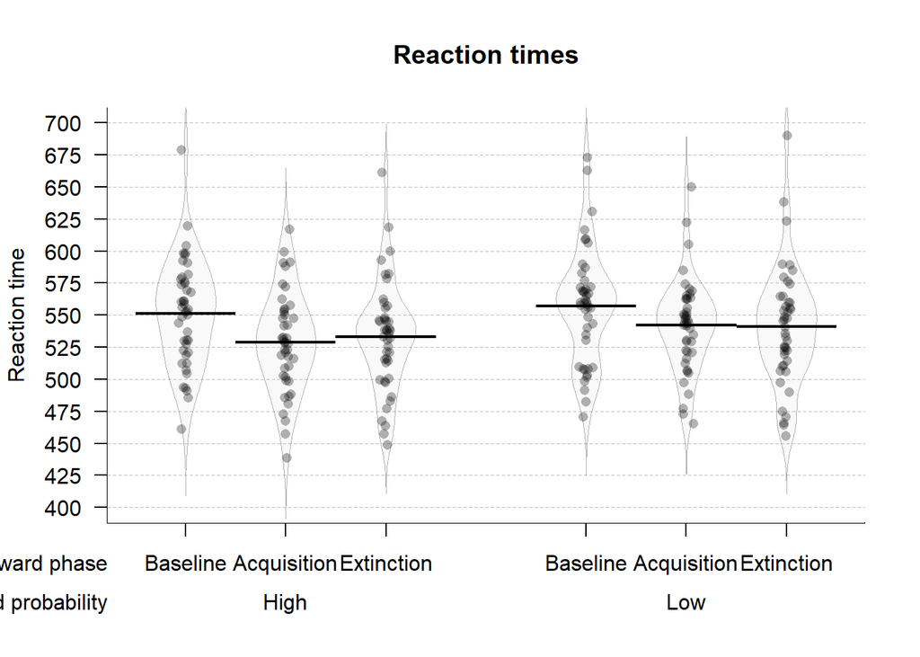

```r
# Prepare the dataset
data.plot = data.final

# rename variables
colnames(data.plot)[colnames(data.plot)=="ExpPhase"] = "Reward phase"
colnames(data.plot)[colnames(data.plot)=="Condition"] = "Reward probability"

# rename conditions
data.plot$`Reward phase` = recode(data.plot$`Reward phase`,
                                "Acq" = "Acquisition",
                                "Bsln" = "Baseline",
                                "Ext" = "Extinction")

data.plot$`Reward probability` = recode(data.plot$`Reward probability`,
                                      "High_Rew" = "High",
                                      "Low_Rew" = "Low")

# Pirate plot
  pirateplot(formula = Hits.RTs ~ `Reward phase` + `Reward probability`, # dependent~independent variables
             data=data.plot, # data frame
             main="Reaction times", # main title
             ylim=c(400,700), # y-axis: limits
             ylab="Reaction time", # y-axis: label
             theme=0, # preset theme (0: use your own)
             point.col="black", # points: color
             point.o=.3, # points: opacity (0-1)
             avg.line.col="black", # average line: color
             avg.line.lwd=2, # average line: line width
             avg.line.o=1, # average line: opacity (0-1)
             bean.b.col="black", # bean border, color
             bean.lwd=0.6, # bean border, line width
             bean.lty=1, # bean border, line type (1: solid; 2:dashed; 3: dotted; ...)
             bean.b.o=0.3, # bean border, opacity (0-1)
             bean.f.col="gray", # bean filling, color
             bean.f.o=.1, # bean filling, opacity (0-1)
             cap.beans=FALSE, # max and min values of bean densities are capped at the limits found in the data
             gl.col="gray", # gridlines: color
             gl.lty=2, # gridlines: line type (1: solid; 2:dashed; 3: dotted; ...)
             cex.lab=1, # axis labels: size
             cex.axis=1, # axis numbers: size
             cex.names = 1,
             bty="l", # plot box type
             back.col="white") # background, color
```

### Statistics

```r
# Set the working directory in order to load the models
# Set working directory
setwd(here("brms_models"))
#
# referencing for easier interpretation
# data.final$ExpPhase=relevel(data.final$ExpPhase,ref="Bsln")
# data.final$Condition=relevel(data.final$Condition,ref="High_Rew")
#
# # Null model
# model.null.RT = brm(Hits.RTs ~ 1 + (1|ParticipantNo),
#                  data=data.final,
#                  family=gaussian(),
#                  warmup = 2000,
#                  iter = 10000,
#                  save_all_pars = TRUE,
#                  control = list(adapt_delta = 0.99),
#                  cores = 4,
#                  sample_prior = TRUE)
# saveRDS(model.null.RT,file="nullmodel.RT.rds")
#
# # ExpPhase model
# model.expphase.RT = brm(Hits.RTs ~ ExpPhase + (ExpPhase|ParticipantNo),
#                  data=data.final,
#                  family=gaussian(),
#                  warmup = 2000,
#                  iter = 10000,
#                  save_all_pars = TRUE,
#                  control = list(adapt_delta = 0.99),
#                  cores = 4,
#                  sample_prior = TRUE)
# saveRDS(model.expphase.RT,file="expphasemodel.RT.rds")
#
# #Interaction model
# model.full.RT = brm(Hits.RTs ~ ExpPhase * Condition + (ExpPhase * Condition|ParticipantNo),
#                  data=data.final,
#                  family=gaussian(),
#                  warmup = 2000,
#                  iter = 10000,
#                  save_all_pars = TRUE,
#                  control = list(adapt_delta = 0.99),
#                  cores = 4,
#                  sample_prior = TRUE)
# saveRDS(model.full.RT,file="model.full.RT.rds")
#
# #WAIC
# compare.RT.waic = WAIC(model.null.RT,model.expphase.RT,model.full.RT, comapre = TRUE)
# saveRDS(compare.RT.waic,file="compare.RT.waic")
#
# # Weighted waic
# compare.RT.waic.weights = model_weights(model.null.RT,model.expphase.RT,model.full.RT, weights = "waic")
# saveRDS(compare.RT.waic.weights,file="compare.RT.waic.weights")
#
# # Bayesian R2
# #Null
# bR2.null.RT = bayes_R2(model.null.RT)
# saveRDS(bR2.null.RT,file="bR2.null.RT")
# #ExpPhase
# bR2.expphase.RT = bayes_R2(model.expphase.RT)
# saveRDS(bR2.expphase.RT,file="bR2.expphase.RT")
# #Full
# bR2.full.RT = bayes_R2(model.full.RT)
# saveRDS(bR2.full.RT,file="bR2.full.RT")

# # read in the models and comparisons

# model.null.RT = readRDS("nullmodel.RT.rds")
# model.expphase.RT = readRDS("expphasemodel.RT.rds")
model.full.RT = readRDS("model.full.RT.rds")
compare.waic.RT = readRDS("compare.RT.waic")
compare.RT.waic.weights = readRDS("compare.RT.waic.weights")
bR2.null.RT = readRDS("bR2.null.RT")
bR2.expphase.RT = readRDS("bR2.expphase.RT")
bR2.full.RT = readRDS("bR2.full.RT")
```

### Model comparison with WAIC

```r
print(compare.waic.RT)
```

```
##                                      WAIC    SE
## model.null.RT                     2541.30 26.80
## model.expphase.RT                 2511.86 27.49
## model.full.RT                     2324.94 23.46
## model.null.RT - model.expphase.RT   29.44 11.92
## model.null.RT - model.full.RT      216.36 18.93
## model.expphase.RT - model.full.RT  186.92 17.80
```

### Bayesian R squared

Null model

```r
print(bR2.null.RT)
```

```
##    Estimate  Est.Error      Q2.5     Q97.5
## R2 0.584279 0.03049892 0.5184536 0.6374979
```

Experiment phase model

```r
print(bR2.expphase.RT)
```

```
##     Estimate  Est.Error      Q2.5     Q97.5
## R2 0.6484994 0.02806138 0.5888214 0.6997926
```

Full model

```r
print(bR2.full.RT)
```

```
##     Estimate  Est.Error      Q2.5     Q97.5
## R2 0.8666485 0.01580508 0.8315594 0.8934709
```

### Checking the best model

Plotting the chains

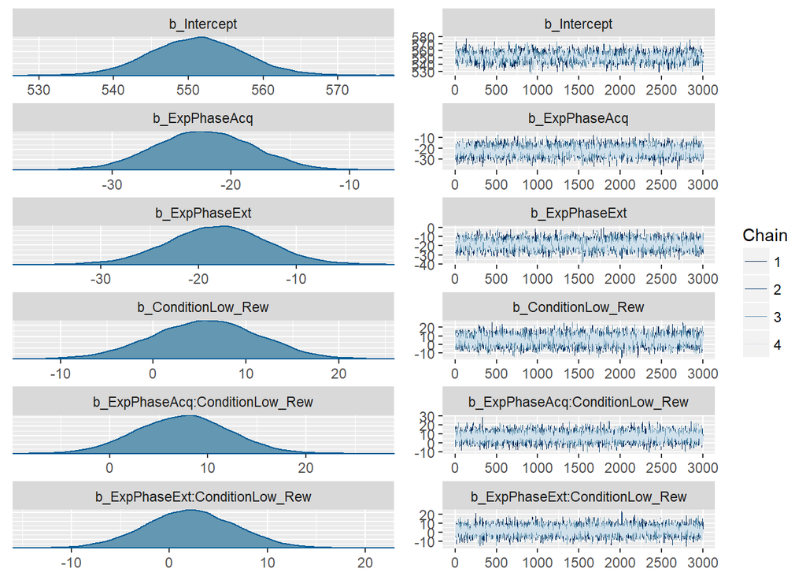

```r
# Plot chains
plot(model.full.RT, pars = "^b_", ask = FALSE, N=6)
```

Summary of the best model

```r
# Summary of the best model
print(tidy(model.full.RT, par_type = "non-varying"), digits = 1)
```

```
##                           term estimate std.error lower upper
## 1                    Intercept      551         6 540.9   561
## 2                  ExpPhaseAcq      -22         4 -29.0   -15
## 3                  ExpPhaseExt      -18         5 -26.4   -10
## 4             ConditionLow_Rew        6         6  -4.0    15
## 5 ExpPhaseAcq:ConditionLow_Rew        7         5  -0.3    15
## 6 ExpPhaseExt:ConditionLow_Rew        2         5  -5.6    10
```

### Plotting the best model

#### Sample from the posterior

```r
# Analyzing the posterior and differences between conditions

post = posterior_samples(model.full.RT, "^b")


################################################ Baseline ####

######### High reward
Baseline_High = post[["b_Intercept"]]
######### Low reward
Baseline_Low = post[["b_Intercept"]] +
  post[["b_ConditionLow_Rew"]]

################################################ Acquistion

######### High reward
Acquisition_High = post[["b_Intercept"]] +
  post[["b_ExpPhaseAcq"]]
######### Low reward
Acquisition_Low = post[["b_Intercept"]] +
  post[["b_ExpPhaseAcq"]] +
  post[["b_ConditionLow_Rew"]] +
  post[["b_ExpPhaseAcq:ConditionLow_Rew"]]

################################################ Extinction

######### High reward
Extinction_High = post[["b_Intercept"]] +
  post[["b_ExpPhaseExt"]]
######### Low reward
Extinction_Low = post[["b_Intercept"]] +
  post[["b_ExpPhaseExt"]] +
  post[["b_ConditionLow_Rew"]] +
  post[["b_ExpPhaseExt:ConditionLow_Rew"]]
```

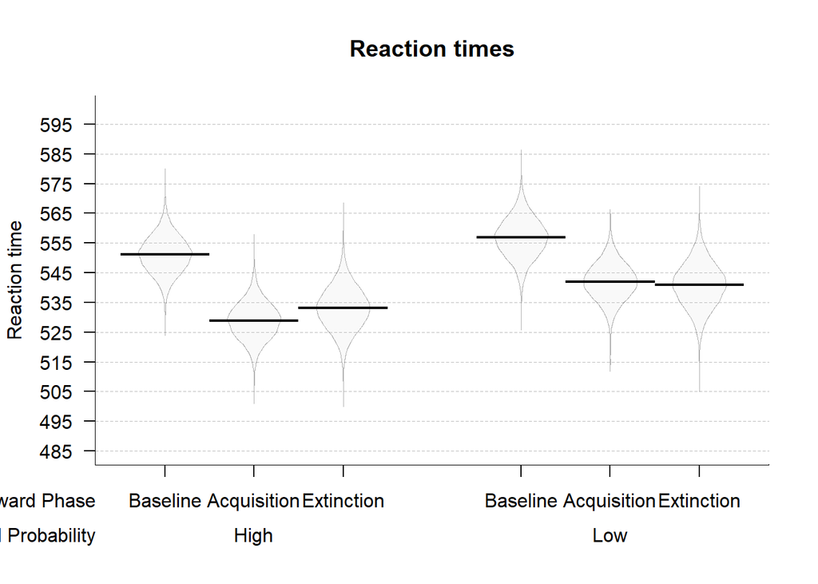

```r
# make a data frame
posterior_conditions = melt(data.frame(Baseline_High, Baseline_Low, Acquisition_High, Acquisition_Low, Extinction_High, Extinction_Low))

posterior_conditions =  posterior_conditions %>% separate(variable, c("Reward Phase", "Reward Probability"), "_", extra = "merge")

names(posterior_conditions)[3] = "Reaction time"



# Pirate plot
pirateplot(formula = `Reaction time` ~ `Reward Phase` + `Reward Probability`, # dependent~independent variables
            data=posterior_conditions, # data frame
             main="Reaction times", # main title
             ylim=c(485,600), # y-axis: limits
             ylab="Reaction time", # y-axis: label
             theme=0, # preset theme (0: use your own)
             avg.line.col="black", # average line: color
             avg.line.lwd=2, # average line: line width
             avg.line.o=1, # average line: opacity (0-1)
             bean.b.col="black", # bean border, color
             bean.lwd=0.6, # bean border, line width
             bean.lty=1, # bean border, line type (1: solid; 2:dashed; 3: dotted; ...)
             bean.b.o=0.3, # bean border, opacity (0-1)
             bean.f.col="gray", # bean filling, color
             bean.f.o=.1, # bean filling, opacity (0-1)
             cap.beans=FALSE, # max and min values of bean densities are capped at the limits found in the data
             gl.col="gray", # gridlines: color
             gl.lty=2, # gridlines: line type (1: solid; 2:dashed; 3: dotted; ...)
             cex.lab=1, # axis labels: size
             cex.axis=1, # axis numbers: size
             cex.names = 1,
             sortx = "sequential",
             bty="l", # plot box type
             back.col="white") # background, color
```

Table of means across conditions

```r
library(HDInterval)

# Make a table with conditions
posterior_means = as.data.frame(c("Baseline High Reward",
                                  "Baseline Low Reward",
                                  "Acquisition High Reward",
                                  "Acquisition Low Reward",
                                  "Extinction High Reward",
                                  "Extinction Low Reward"))
names(posterior_means)[1] = "Condition"

posterior_means$Mean = c(paste(round(mean(Baseline_High), digits = 2), " [", round(hdi(Baseline_High)[[1]], digits = 2), " ", round(hdi(Baseline_High)[[2]], digits = 2), "]"),
                        paste(round(mean(Baseline_Low), digits = 2), " [", round(hdi(Baseline_Low)[[1]], digits = 2), " ", round(hdi(Baseline_Low)[[2]], digits = 2), "]"),
                        paste(round(mean(Acquisition_High), digits = 2), " [", round(hdi(Acquisition_High)[[1]], digits = 2), " ", round(hdi(Acquisition_High)[[2]], digits = 2), "]"),
                        paste(round(mean(Acquisition_Low), digits = 2), " [", round(hdi(Acquisition_Low)[[1]], digits = 2), " ", round(hdi(Acquisition_Low)[[2]], digits = 2), "]"),
                        paste(round(mean(Extinction_High), digits = 2), " [", round(hdi(Extinction_High)[[1]], digits = 2), " ", round(hdi(Extinction_High)[[2]], digits = 2), "]"),
                        paste(round(mean(Extinction_Low), digits = 2), " [", round(hdi(Extinction_Low)[[1]], digits = 2), " ", round(hdi(Extinction_Low)[[2]], digits = 2), "]"))

names(posterior_means)[2] = "Mean [HDI]"

posterior_means =  posterior_means %>% separate(Condition, c("Reward Phase", "Reward Probability"), " ", extra = "merge")

kable(posterior_means, caption = "Means per condition")
```

Means per condition

| Reward Phase | Reward Probability | Mean [HDI] |
| --- | --- | --- |
| Baseline | High Reward | 551.15 [ 538.76 563.4 ] |
| Baseline | Low Reward | 556.82 [ 543.65 570.1 ] |
| Acquisition | High Reward | 528.87 [ 516.89 541.25 ] |
| Acquisition | Low Reward | 542.01 [ 530.03 554.53 ] |
| Extinction | High Reward | 533.06 [ 518.87 547.36 ] |
| Extinction | Low Reward | 540.89 [ 526.07 555.71 ] |

### Inference about the best model

Check the difference between high reward in baseline vs. acquisition

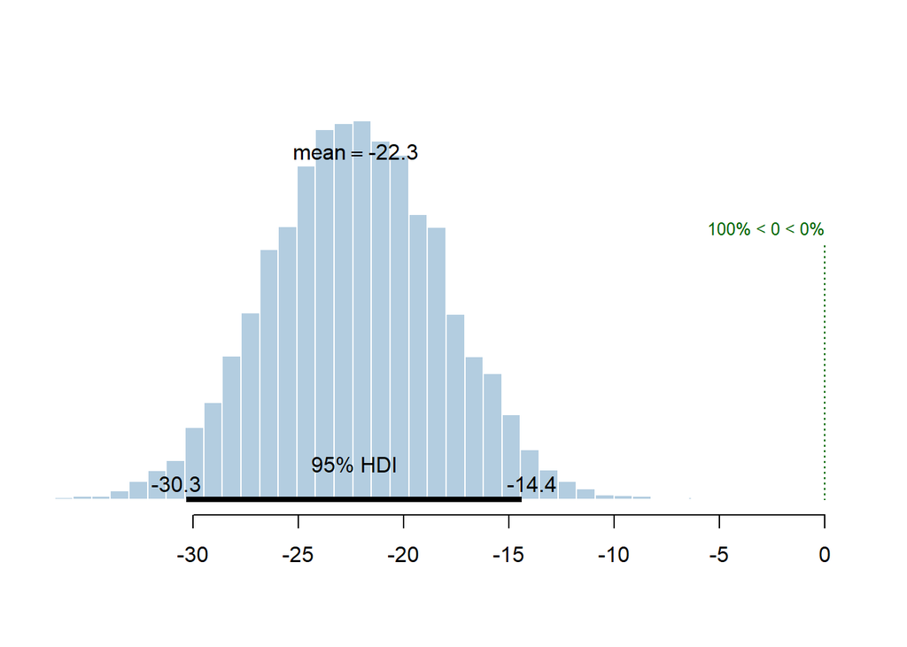

```r
Diff_Bsln_Acq_High = Acquisition_High - Baseline_High
plotPost(Diff_Bsln_Acq_High, xlab = "", col = "#b3cde0", showCurve = FALSE, cex = 1, compVal = 0)
```

Check the difference between low reward in baseline vs. acquisition

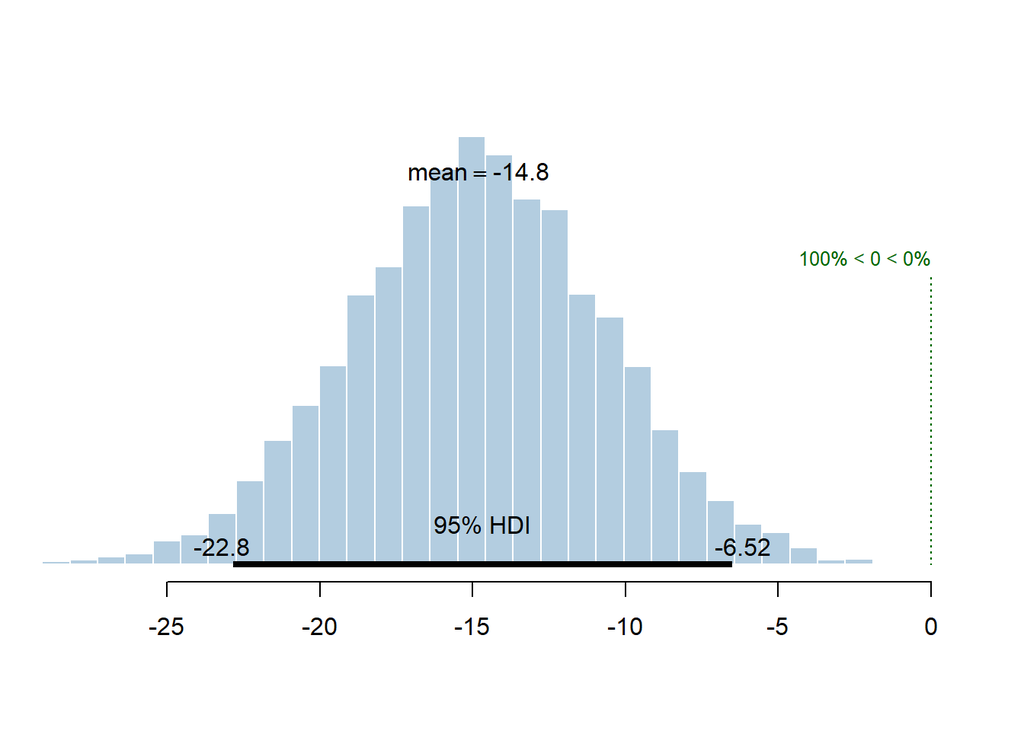

```r
Diff_Bsln_Acq_Low = Acquisition_Low - Baseline_Low
plotPost(Diff_Bsln_Acq_Low, xlab = "", col = "#b3cde0", showCurve = FALSE, cex = 1, compVal = 0)
```

Check the difference between high and low reward in baseline vs. acquisition

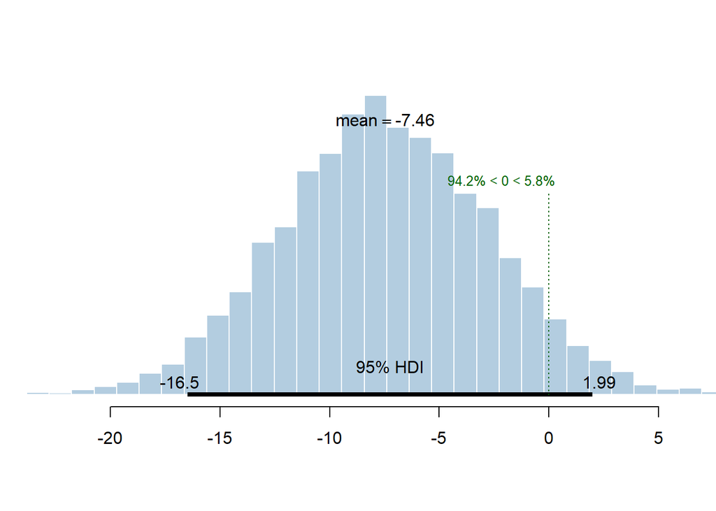

```r
Diff_Bsln_Acq_High_vs_Low = Diff_Bsln_Acq_High - Diff_Bsln_Acq_Low
plotPost(Diff_Bsln_Acq_High_vs_Low, xlab = "", col = "#b3cde0", showCurve = FALSE, cex = 1, compVal = 0)
```

```r
paste("Mean = ",round(mean(Diff_Bsln_Acq_High_vs_Low), digits = 2), " [", round(hdi(Diff_Bsln_Acq_High_vs_Low)[[1]], digits = 2), " ", round(hdi(Diff_Bsln_Acq_High_vs_Low)[[2]], digits = 2), "]")
```

```
## [1] "Mean =  -7.46  [ -16.49   1.99 ]"
```

Check the difference between high reward in acquisition vs. extinction

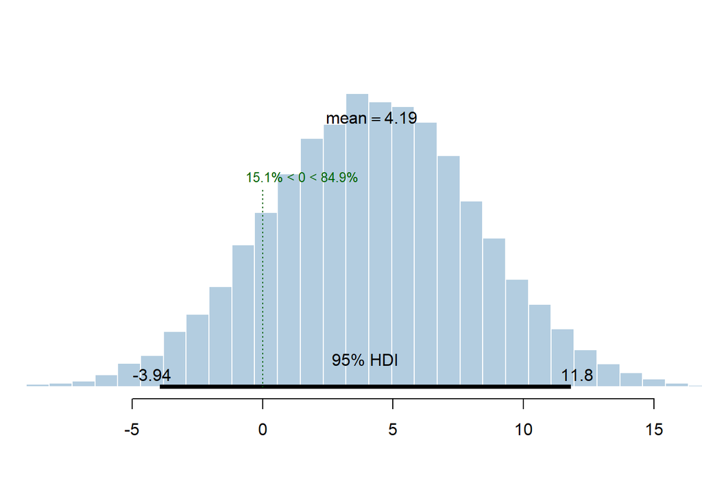

```r
Diff_Acq_Ext_High = Extinction_High - Acquisition_High
plotPost(Diff_Acq_Ext_High, xlab = "", col = "#b3cde0", showCurve = FALSE, cex = 1, compVal = 0)
```

Check the difference between low reward in acquisition vs. extinction

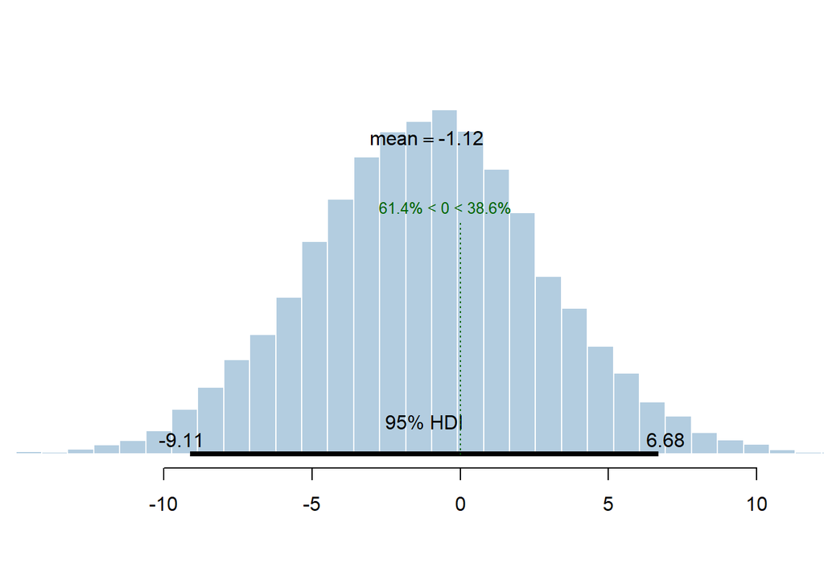

```r
Diff_Acq_Ext_Low = Extinction_Low - Acquisition_Low
plotPost(Diff_Acq_Ext_Low, xlab = "", col = "#b3cde0", showCurve = FALSE, cex = 1, compVal = 0)
```